# Expected credit loss

01/07/2021

## Aim of this presentation

The aim of this presentation is to model and present the various techniques of working with expected credit losses using real life data.

The subject in this presentation will be one of the biggest short term loan lenderer in US: **Lending Club**.

[figure not shown]

## Acknowledgment

All the logic and models are presented in the course https://www.udemy.com/course/credit-risk-modeling-in-python

The presenter of the material is Nikolay G. Georgiev, PhD from the Norwegian Business School.

The data is taken from kaggle https://www.kaggle.com/ethon0426/lending-club-20072020q1

Lending club website https://www.lendingclub.com/

## Expected credit loss

\[ \mathbb E[CL] = \mathbb E[PD] \mathbb E[LGD] \mathbb E[EAD] \] CL - Credit losses

PD - Probability of default

LGD - Losses given default

EAD - Exposure at default

## Exploring the data

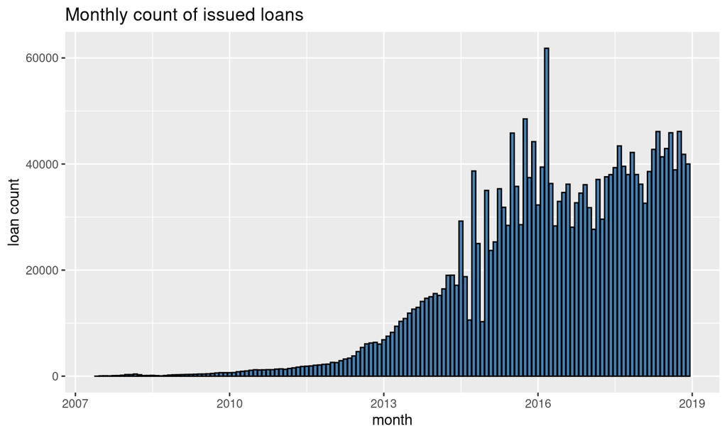

## Loan status

There is a feature in the data called **loan_status**. The values can be:

```
##                                            loan_status       N
## 1:                                             Default     351
## 2: Does not meet the credit policy. Status:Charged Off     757
## 3:                                   Late (16-30 days)    1518
## 4:  Does not meet the credit policy. Status:Fully Paid    1957
## 5:                                     In Grace Period    5627
## 6:                                  Late (31-120 days)    9499
## 7:                                         Charged Off  347810
## 8:                                             Current  458491
## 9:                                          Fully Paid 1427932
```

## Bad loans

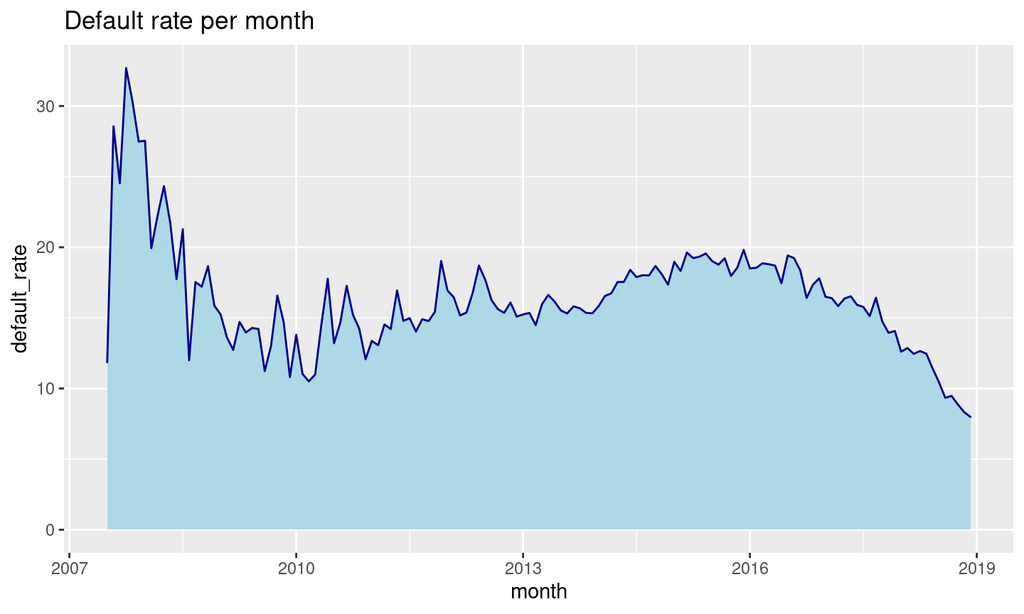

## Distribution by grade

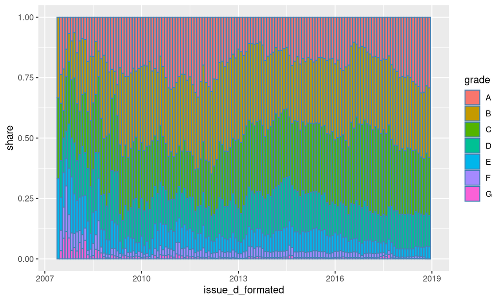

## The Basel Accords

The Basel II accord, which was signed in 2004, defined three strict guidelines:

- How much capital banks need to have
- How capital is defined
- How capital is compared against risk-weighted assets

One of the main takeouts from both the basel II and subsequent basel III accords is that

**The greater the risk a bank is exposed to, the greater the amount of capital it needs to hold**

## Probability of default (PD)

This is the most strict part of the three components of ECL and must follow certain rules in modeling. Every feature, both categorical and numeric, needs to be transformed into dummy variables.

To infer what categorical feature values are the most influential in determining bad loan from a good loan we can use the weight of evidence (WOE for short) criteria. For a feature \(i\) and the feature level \(j\) the \(WOE_{i, j}\) is calculated with the following formula:

\[WOE_{i, j} = log \left(\dfrac{P(X_{i}=j|Y=1)}{P(X_{i} = j|Y=0)}\right)\]

## WOE example

```
##      feature    bad    good prop_good  prop_bad        woe
## 1: 36 months 214070 1390942  0.733803 0.5972652  0.2058794
## 2: 60 months 144347  504583  0.266197 0.4027348 -0.4140418
```

## WOE for interest rates

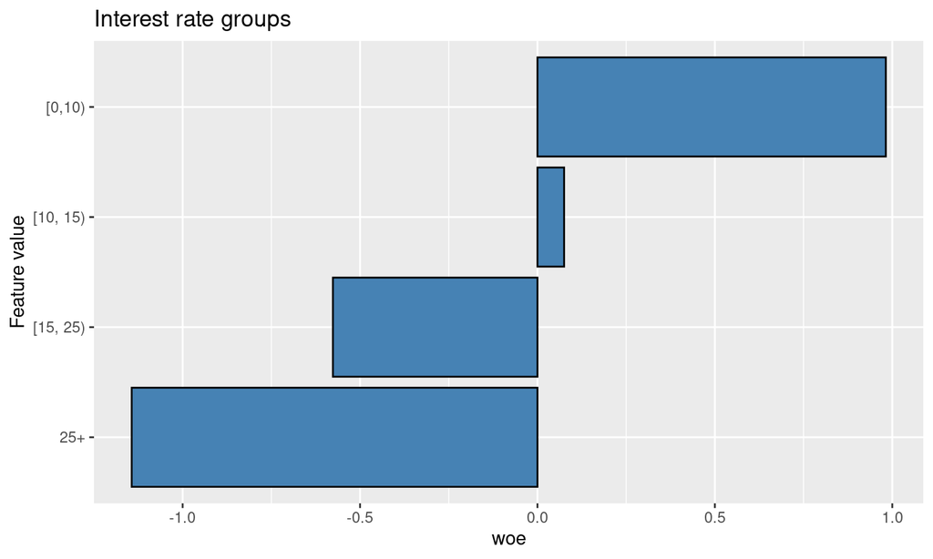

## Annual income

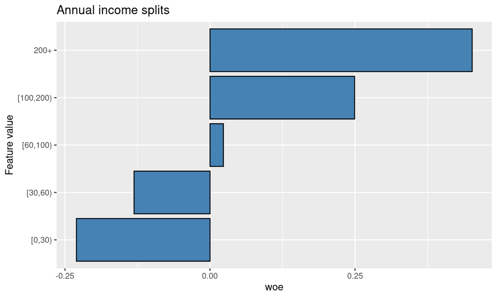

## Some more features

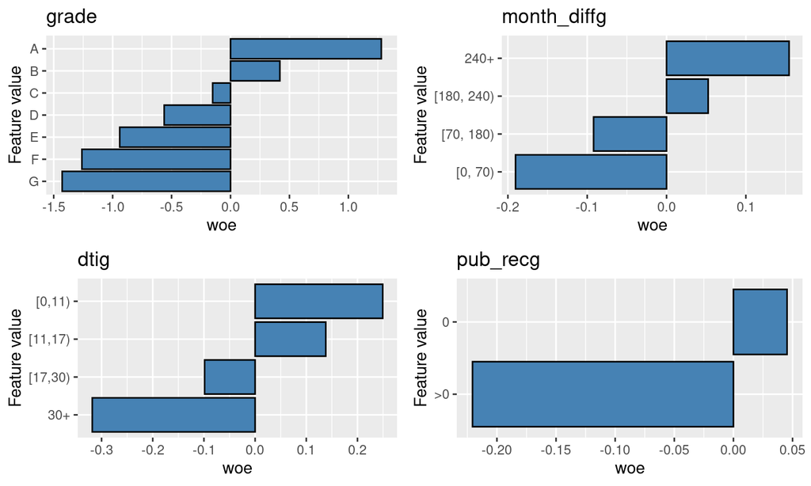

## Final variable list used for PD

term

pub_rec

annual_inc

dti

month_diff

emp_length

int_rate

loan_amnt

grade

## Machine learning method

Now that we have our \(X\) matrix and our \(Y\) matrix, we need a method to model the relationship between them.

A popular choice is the **logistic regression** model for binary classification.

We want to estimate the following conditional probability:

\[P(Y = 1|X)\]

In our case:

\[P(Y = "good-loan"| "data")\]

## Logistic regression - regression part

**Regress** - “coming back to” (liet. - grįžimas).

The term is accredited to Francis Galton in the 19th century in his biological work.

**Regression** \(\approx\) “coming back to the mean”

Regression models try to model the expected value (average) of the dependent variable with the independent ones.

In general terms:

\[\mathbb E[Y|X] = \mu = g^{-1}(\beta_{0} + \Sigma_{i=1}^{k} \left( \beta_{i} X_{i} \right)) \]

\(g(.)\) is called the link function.

## Logistic regression - logistic part

The standard logistic function is:

\[ logistic(x) = \dfrac{1}{1 + e^{-x}} \]

\[ logistic : (-\infty, +\infty) \rightarrow (0, 1) \]

The logit (log-odds) function is:

\[logit(x) = log(\dfrac{x}{1-x})\]

\[logit: (0, 1) \rightarrow (-\infty, +\infty)\]

\[logit^{-1}(x) = logistic(x)\]

## Logistic regression equation

Putting “logistic” and “regression” together:

Lets define:

\[z := \beta_{0} + \Sigma_{i=1}^{k} \left( \beta_{i} X_{i} \right)) \]

Logistic regression is form of general linear models (GLM) where the link function is the logit function.

\[ \mathbb E[Y|X] = logit^{-1}(z) = logistic(z) = \dfrac{1}{1 + e^{-z}}\]

## Estimating the coefficients

The way we obtain the coefficients \(\beta\) is by using a procedure called maximum likelihood (ML).

\[\Pi_{i=1}^{n} \left[ P(Y=1|X) ^ {y_{i}} (P(Y=0|X)^{1 - y_{i}}) \right] \rightarrow max\]

\[L(\beta | Y, X) = \Pi_{i=1}^{n} \left[ logistic(z) ^ {y_{i}} ((1 - logistic(z))^{1 - y_{i}}) \right]\]

\[l(\beta| Y, X) = log(L ( \beta | Y, X)) \]

\[ l(\beta) = \Sigma_{i=1}^{n}\left[y_{i} log(logisitc(z)) + (1 - y_{i})log(1 - logistic(z)) \right] \]

The computer tries to find the “best” \(\beta\) values such that the probability is as big as possible for witnessing the Y in our sample from the given X.

## The model for PD

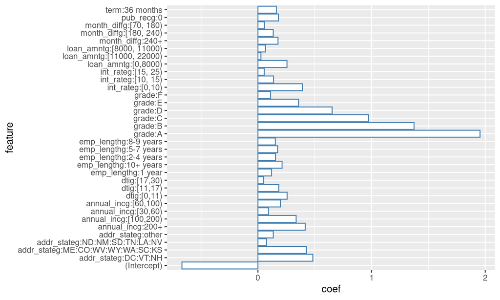

## Results on the test set

```
FALSE Setting levels: control = bad, case = good
```

```
FALSE Setting direction: controls < cases
```

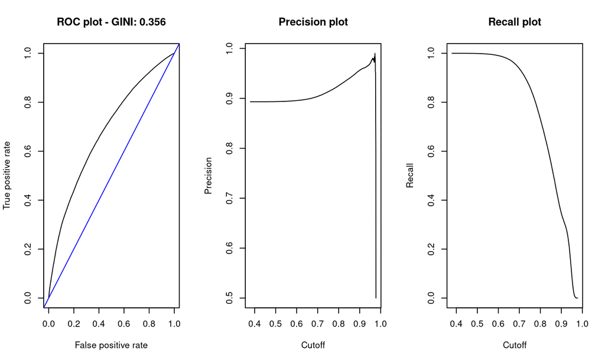

## Converting to a scorecard

We will recalibrate the coefficients to be between 200 and 800.

```
##     origFeature    min_coef   max_coef
##  1: (Intercept) -0.66869436 -0.6686944
##  2: addr_stateg  0.07568607  0.4834059
##  3:  annual_inc  0.00000000  0.0000000
##  4: annual_incg  0.09287882  0.4164900
##  5:         dti  0.00000000  0.0000000
##  6:        dtig  0.04985094  0.2572548
##  7:  emp_length  0.00000000  0.0000000
##  8: emp_lengthg  0.11924258  0.2122818
##  9:       grade  0.00000000  1.9544585
## 10:    int_rate  0.00000000  0.0000000
## 11:   int_rateg  0.05588417  0.3916231
## 12:   loan_amnt  0.00000000  0.0000000
## 13:  loan_amntg  0.02623375  0.2557224
## 14:  month_diff  0.00000000  0.0000000
## 15: month_diffg  0.05755514  0.1766704
## 16:     pub_rec  0.00000000  0.0000000
## 17:    pub_recg  0.18033526  0.1803353
## 18:        term  0.00000000  0.1626457
```

## Formulas for converting

To convert the coefficient to a score, we need to follow the following formula:

\[score = coef\dfrac{(max\_score - min\_score)}{maxsum\_coef - minsum\_coef}\]

To adjust the coefficient for the intercept we will use the formula:

\[ score\_intercept = \dfrac{(intercept\_coef - min\_sum\_coef)}{(max\_sum\_coef - min\_sum\_coef)} (max\_score - min\_score) + min\_score \]

## Final scorecard

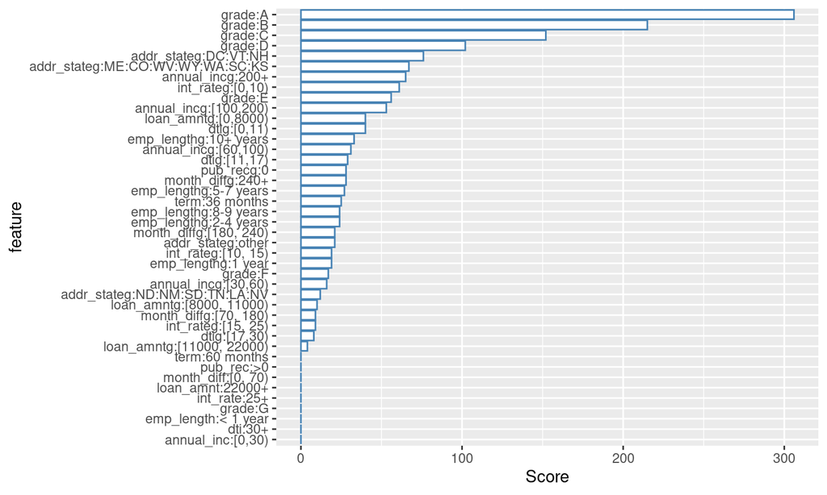

## EAD modeling - Y variable

The dependent variable for the exposure at default is the amount of funds that a bank is at risk at a default event. They way we model it is using a variable called credit conversion factor (CCF):

\[ CCF_{i} = \dfrac{funded\_amount_{i} - received\_payments_{i}}{funded\_amount_{i}} \]

The higher the CCF for a given loan, the bigger is the EAD sum:

\[ EAD_{i} = CCF_{i} * funded\_amount_{i} \]

## EAD Y variable distribution

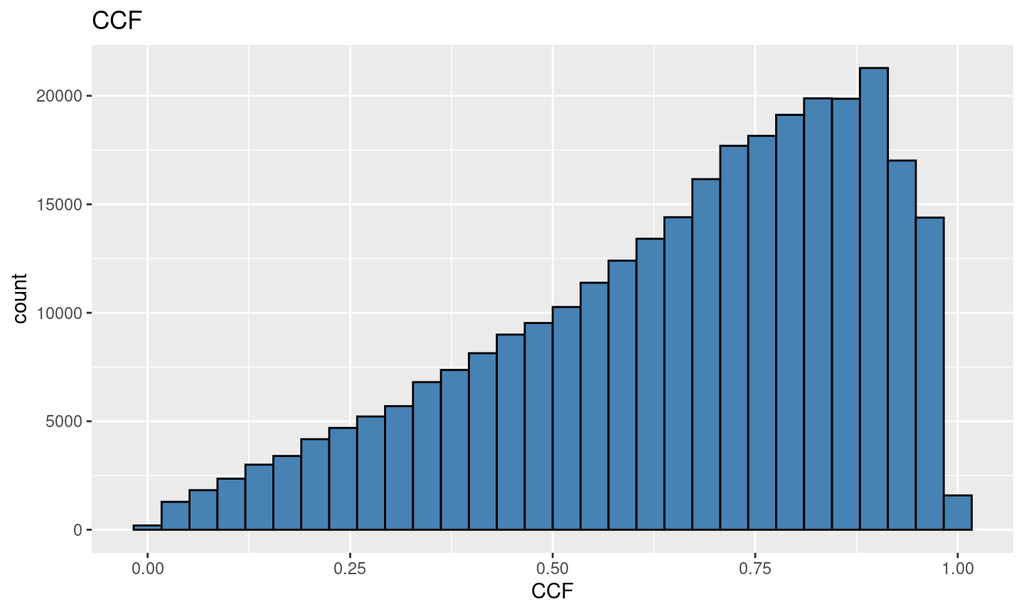

## The model for EAD

| V1 | feature | coef |
| --- | --- | --- |
| 1 | (Intercept) | -2.6245605 |
| 2 | term60 months | 0.1169728 |
| 3 | pub_recg>0 | 0.0702710 |
| 4 | annual_inc | 0.0000019 |
| 5 | dti | 0.0078021 |
| 6 | month_diff | 0.0001080 |
| 7 | int_rate | 0.0010157 |
| 8 | loan_amnt | -0.0000012 |
| 9 | gradeB | 0.0372539 |
| 10 | gradeC | 0.1286406 |
| 11 | gradeD | 0.1519879 |
| 12 | gradeE | 0.1953546 |
| 13 | gradeF | 0.2035584 |
| 14 | gradeG | 0.2542867 |
| 15 | addr_stategME:CO:WV:WY:WA:SC:KS | 0.0164877 |
| 16 | addr_stategND:NM:SD:TN:LA:NV | 0.1306549 |
| 17 | addr_stategOK:AL:AR:MS:NE | 0.1499764 |
| 18 | addr_stategother | 0.0973162 |

## EAD residuals in the test set

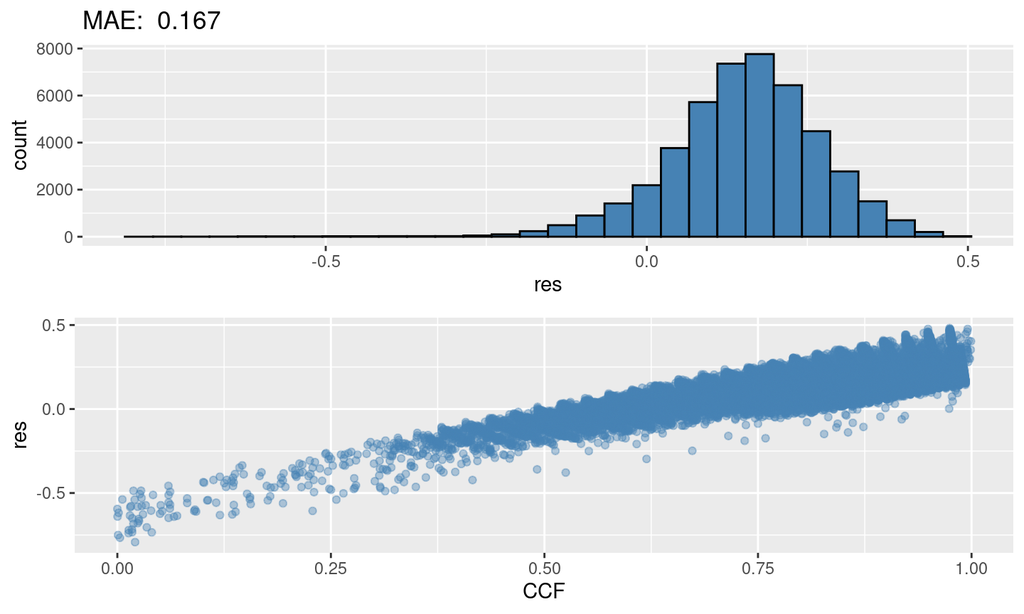

## LGD modeling - Y variable

LGD stands for losses given default. When dealing with loan data we can model recovery rate. Then, for each loan,

\[ LGD = 1 - recovery\_rate \] In this data set, we calculate the recovery rate using the following equation:

\[ rt_{i} = \dfrac{recoveries_{i}}{funded\_amount_{i}} \]

\(i\) - loan \(i\).

When modeling the rt in this dataset we need to take into account only those loans who were charged off.

## LGD Y variable distribution

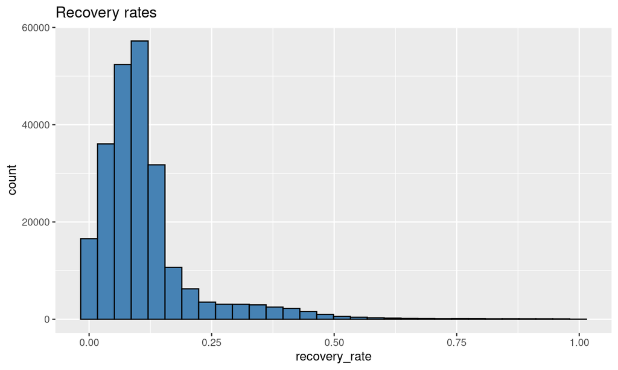

## The model for LGD

[output not shown]

## LGD residuals in the test set

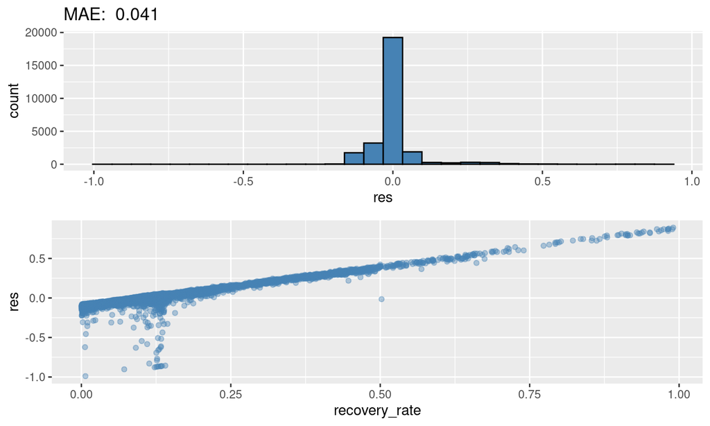

## Combining all the parts together

The final ECL estimate using the dependant variables we estimated:

\[ ECL =(1 - P(Y=1)) * (1 - recovery\_rate) * CCF * loan\_amount \]

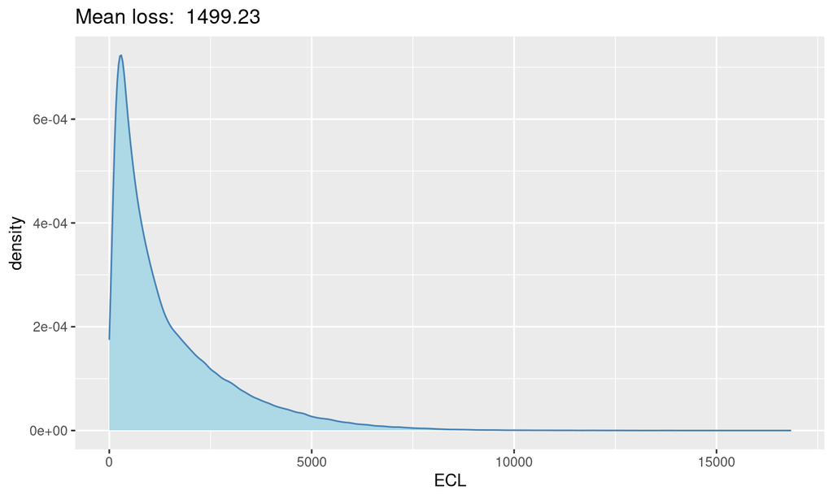

## Absolute residual distribution

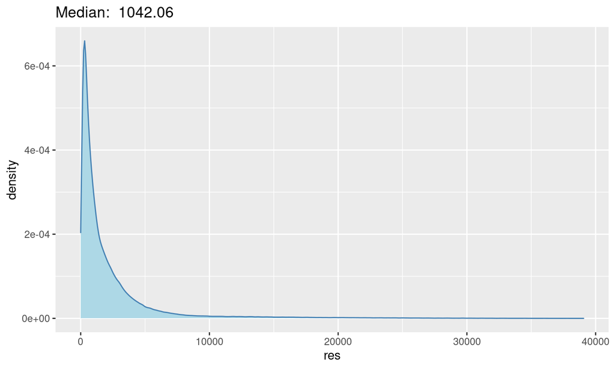